# Practical Class: Data Analysis for the Mental Rotation Task

# Instructions

- Download [this zip file](https://michael-franke.github.io/XPLab_2019/handouts/mental_rotation_analysis.zip).
- Download the results file from Stud.IP.
- Open the .Rmd file in RStudio.
- Fill in the code required (ask for help if needed!)
- When you’re done: ‘Knit’ the document (`ctrl/cmd` + `shift` + `K` in RStudio) to produce a HTML file.

# Suggested resources

- [RStudio cheatsheets](https://www.rstudio.com/resources/cheatsheets/).

# Required R packages

- `tidyverse` (or `ggplot2`, `dplyr`, `purrr`, `tibble`)
- `brms`
- `devtools` (for installing `faintr`)
- `rstan`
- `faintr` (install with `devtools`)

Load the required packages and set a seed for the random number generator.

```r
library(tidyverse)

library(rstan)
# set cores to use to the total number of cores (minimally 4)
options(mc.cores = max(parallel::detectCores(), 4))
# save a compiled version of the Stan model file
rstan_options(auto_write = TRUE)

library(brms)

# install faintr with devtools::install_github('michael-franke/bayes_mixed_regression_tutorial/faintr', build_vignettes = TRUE))
library(faintr)


set.seed(123)
```

## Step 1. Read the data and take a glimpse of it.

Use `read_csv()` and `glimpse()`

```r
# your code here
data<-read_csv("mrt_results.csv")
glimpse(data)
```

```
## Observations: 1,620
## Variables: 20
## $ submission_id <dbl> 7940, 7940, 7940, 7940, 7940, 7940, 7940, 7940, 79…
## $ RT            <dbl> 4760, 2381, 2650, 2272, 2026, 2386, 2112, 2168, 31…
## $ age           <dbl> 22, 22, 22, 22, 22, 22, 22, 22, 22, 22, 22, 22, 22…
## $ angle         <dbl> 150, 50, 150, 50, 50, 150, 150, 150, 150, 50, 50, …
## $ comments      <chr> NA, NA, NA, NA, NA, NA, NA, NA, NA, NA, NA, NA, NA…
## $ correctness   <chr> "correct", "correct", "correct", "correct", "corre…
## $ education     <chr> "Graduated High School", "Graduated High School", …
## $ endTime       <dbl> 1.558597e+12, 1.558597e+12, 1.558597e+12, 1.558597…
## $ expected      <chr> "same", "different", "different", "same", "same", …
## $ experiment_id <dbl> 57, 57, 57, 57, 57, 57, 57, 57, 57, 57, 57, 57, 57…
## $ gender        <chr> "female", "female", "female", "female", "female", …
## $ item          <dbl> 15, 15, 15, 15, 13, 13, 13, 14, 14, 14, 13, 14, 12…
## $ key_pressed   <chr> "f", "j", "j", "f", "f", "j", "f", "f", "f", "f", …
## $ languages     <chr> "German", "German", "German", "German", "German", …
## $ picture       <chr> "images/practice/15_150_same.jpg", "images/practic…
## $ startDate     <chr> "Thu May 23 2019 09:20:31 GMT+0200 (Mitteleuropäis…
## $ startTime     <dbl> 1.558596e+12, 1.558596e+12, 1.558596e+12, 1.558596…
## $ timeSpent     <dbl> 9.6116, 9.6116, 9.6116, 9.6116, 9.6116, 9.6116, 9.…
## $ trial_number  <dbl> 1, 2, 3, 4, 5, 6, 7, 8, 9, 10, 11, 12, 1, 2, 3, 4,…
## $ trial_type    <chr> "practice", "practice", "practice", "practice", "p…
```

## Step 2. Select only the columns of interest.

Do this with the `select()` command.

```r
# your code here
data <- select(data,expected,RT,angle,correctness,item,submission_id, trial_type)
```

## Step 3. Change columns to the correct data type.

Use `mutate()`: * `expected` should be a factor (also rename this to `condition`) * `correctness` should be a factor * `angle` should be a factor * `trial_type` should be a factor

```r
# your code here
data<-mutate(data, condition= factor(expected),
       angle= factor(angle),
       correctness= factor(correctness),
       trial_type= factor(trial_type)
       )
```

## Step 4. Show the data frame.

Check that everything is there and of the correct type.

```r
# your code here
data
```

```
## # A tibble: 1,620 x 8
##    expected    RT angle correctness  item submission_id trial_type
##    <chr>    <dbl> <fct> <fct>       <dbl>         <dbl> <fct>
##  1 same      4760 150   correct        15          7940 practice
##  2 differe…  2381 50    correct        15          7940 practice
##  3 differe…  2650 150   correct        15          7940 practice
##  4 same      2272 50    correct        15          7940 practice
##  5 same      2026 50    correct        13          7940 practice
##  6 differe…  2386 150   correct        13          7940 practice
##  7 same      2112 150   correct        13          7940 practice
##  8 differe…  2168 150   incorrect      14          7940 practice
##  9 same      3125 150   correct        14          7940 practice
## 10 same      2640 50    correct        14          7940 practice
## # … with 1,610 more rows, and 1 more variable: condition <fct>
```

## Step 5. Filter only the ‘main’ trials with correct responses.

Use `filter()`.

```r
# your code here
data_filtered <- filter(data, trial_type =='main', correctness=='correct')
```

## Step 6. Make a boxplot of the data.

Show condition (same/different) on the x-axis and RT on the y-axis. Show the different angles in different colors (fill). (use `ggplot()` and `geom_boxplot`)

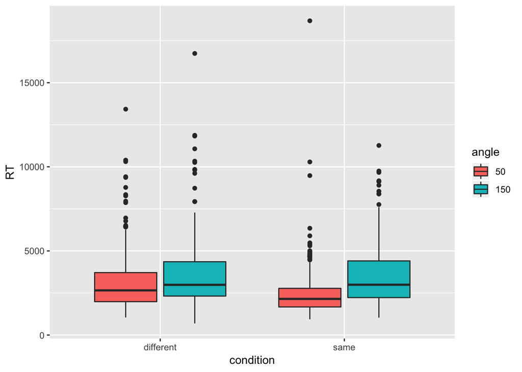

```r
# your code here
ggplot(data_filtered, aes(condition,RT, fill= angle)) +
  geom_boxplot(stat="boxplot")
```

## Step 7. Remove outliers

Use `filter()` to filter only response times that are in a reasonable range.

```r
# your code here
data_filtered <- filter(data_filtered, RT<10000, RT > 2000)
```

## Step 8. Show means for each design cell.

Use `group_by() %>% summarise()`.

```r
# your code here

data_filtered %>% group_by(condition, angle) %>% summarise(mean(RT))
```

```
## # A tibble: 4 x 3
## # Groups:   condition [2]
##   condition angle `mean(RT)`
##   <fct>     <fct>      <dbl>
## 1 different 50         3584.
## 2 different 150        3816.
## 3 same      50         3044.
## 4 same      150        3865.
```

## Step 9. Run a bayesian fixed-effects model

Use `brm` to model the response times from angle, condition and angle*condition.

```r
# your code here
formula = RT ~ angle*condition
model = brm(formula, data_filtered)
```

## Step 10. See how probable the following hypotheses are:

Use `faintr::compare_groups()`

"Responses to ‘same’ trials are faster than responses to ‘different’ trials.

```r
# your code here
compare_groups(model, higher = list(condition='different'), lower = list(condition='same') )
```

```
## Outcome of comparing groups:
##  * higher:  condition:different
##  * lower:   condition:same
## Mean 'higher - lower':  245.3
## 95% CI: [ 33.53 ; 441.5 ]
## P('higher - lower' > 0):  0.988
```

"Responses to ‘50 degree’ trials are faster than responses to ‘150 degree’ trials.

```r
# your code here
compare_groups(model, higher = list(angle='150'), lower = list(angle='50') )
```

```
## Outcome of comparing groups:
##  * higher:  angle:150
##  * lower:   angle:50
## Mean 'higher - lower':  527.2
## 95% CI: [ 323 ; 737.9 ]
## P('higher - lower' > 0):  1
```

“Angle matters more than same/different for response times”. (In other words, when the angle is lower but the objects are ‘different’, people are still faster than when the angle is higher but the objects are the ‘same’.)

```r
# your code here
compare_groups(model, higher = list(angle='150',condition= 'same'), lower = list(angle='50', condition='different'))
```

```
## Outcome of comparing groups:
##  * higher:  angle:150 condition:same
##  * lower:   angle:50 condition:different
## Mean 'higher - lower':  281.9
## 95% CI: [ -6.913 ; 560.2 ]
## P('higher - lower' > 0):  0.9772
```

## Step 11. Run the model again, but this time include random effects

Include random by-item intercepts (`+ (1|item)`).

```r
# your code here
formula = RT ~ angle*condition + (1|item)
model2 = brm(formula, data_filtered)
```

## Step 12. Check the same hypotheses for the mixed effects model

```r
# your code here
compare_groups(model2, higher = list(condition='different'), lower = list(condition='same') )
```

```
## Outcome of comparing groups:
##  * higher:  condition:different
##  * lower:   condition:same
## Mean 'higher - lower':  237.2
## 95% CI: [ 50.1 ; 441.4 ]
## P('higher - lower' > 0):  0.9918
```

```r
compare_groups(model2, higher = list(angle='150'), lower = list(angle='50') )
```

```
## Outcome of comparing groups:
##  * higher:  angle:150
##  * lower:   angle:50
## Mean 'higher - lower':  533.3
## 95% CI: [ 338.5 ; 743.4 ]
## P('higher - lower' > 0):  1
```

```r
compare_groups(model2, higher = list(angle='150',condition= 'same'), lower = list(angle='50', condition='different'))
```

```
## Outcome of comparing groups:
##  * higher:  angle:150 condition:same
##  * lower:   angle:50 condition:different
## Mean 'higher - lower':  296.1
## 95% CI: [ 10.38 ; 559.4 ]
## P('higher - lower' > 0):  0.9848
```

## Step 13. Conclude

End of sheet.